# Amostragem Estratificada

Amostragem Estratificada (AE) é um processo de amostragem que usa alguma informação relevante que deve estar disponível para todos os elementos da população para *dividir a população $U$ em $H$ grupos* disjuntos e exaustivos, geralmente mais *homogêneos*, chamados *estratos* e com a *seleção de amostras dentro de cada um dos estratos*, independentemente.

As variáveis de estratificação podem ser geográficas ou não-geográficas (rendimento, idade, sexo, número de empregados,etc.), sendo limitadas àquelas informações que estão disponíveis no cadastro.

Os parâmetros são estimados em cada estrato, de acordo com o esquema de seleção adotado e as estimativas são agregadas para o conjunto da população.

Dentre as vantagens da AE destacam-se:

- a possibilidade de aumentar a precisão das estimativas para o conjunto da população;
- a garantia de observação de amostras em todos os estratos formados;
- a possibilidade de estimação para subgrupos da população da pesquisa com eficiência e precisão controladas; e
- a viabilidade de ser operacionalmente e/ou administrativamente mais conveniente.

Por outro lado, a AE requer conhecimento das variáveis de estratificação para todas as unidades do cadastro antes da amostragem e a re-estruturação do cadastro antes da amostragem. Apenas uma estratificação é possível e dividir a população em muitos estratos pode levar a ter amostras muito pequenas em cada estrato.

Seguem as razões para estratificar uma população:

1. Estratos formam domínios “naturais” ou substantivos de interesse. Por exemplo: regiões geográficas; farmácias e lojas de departamentos; homens e mulheres; etc.
2. Para “espalhar” a amostra sobre toda a população, isto é, para fazer a amostra “representativa”e assegurar que todas as partes (estratos) da população estão representados na amostra.
3. Para melhorar a eficiência amostral, isto é, para reduzir a variância dos estimadores quanto maior for a homogeneidade dentro dos estratos.
4. Quando for necessário usar métodos diferentes de coleta em diferentes subgrupos da população.

Podemos distinguir dois tipos de estratificação:

1. *Natural* - quando os estratos são iguais a subgrupos da população para os quais se requer estimativas com precisão controlada.
2. *Estatística* - quando os estratos são definidos como subgrupos homogêneos da população, visando aumentar eficiência na estimação para a população como um todo. Neste caso, não há interesse específico na estimação de parâmetros dos estratos formados.

Há diversos fatores que influenciam a eficiência na AE: a escolha da(s) variável(is) de estratificação; o número de estratos; a determinação dos limites dos estratos; a alocação da amostra nos estratos; e o método de seleção da amostra em cada estrato.

Para *estratificação natural* a escolha da(s) variável(is) de estratificação se dá considerando TODAS as variáveis disponíveis com as quais são definidos os estratos naturais ou domínios de interesse da pesquisa.

No caso da *estratificação estatística*, escolha entre as variáveis disponíveis as que são *melhores preditoras* das variáveis de interesse da pesquisa.

Para conseguir ganhar eficiência com o uso da estratificação, a ideia é tornar os valores da(s) variável(is) de estudo dentro de cada estrato os mais similares / homogêneos possíveis, isto é, *minimizar a variância dentro dos estratos*.

Para isso é fundamental ter acesso a cadastro com variáveis auxiliares que possam ser usadas para estratificar a população de forma eficiente.

## O Método Geral

Particione (divida) $U$ em $H$ subconjuntos (grupos) *mutuamente exclusivos e exaustivos*, chamados *estratos*, e denotados por $U_1, ..., U_h, ..., U_H$, de modo que: $U=U_1\cup U_2\cup \dots\cup U_H=\displaystyle\bigcup_{h=1}^H U_h$ e $U_h \cap U_k=\emptyset,\, h\ne k$.

Então $U_h = \textrm {\{unidades pertencentes ao estrato h}\}$, para $h=1,2,...,H$.

Seja $N_h$ o tamanho de $U_h$. Então $N_1+N-2+\dots+N_H=N$.

Selecione uma amostra $a_h$ de tamanho $n_h$, com $n_h>0$, segundo um plano amostral $p_h(a_h)$ *independentemente dentro de cada estrato* $h$, onde $h = 1, 2, ..., H$, e $\displaystyle \sum_{h=1}^{H}n_h=n$.

Assim, fica assegurado que cada estrato tem sua população representada na amostra completa dada por: $s=a_1\cup a_2 \cup\dots\cup a_H$.

A independência da amostragem nos estratos consiste em tratar cada estrato como se fosse uma população separada, para fins de sorteio da amostra.

Devido à independência da seleção nos estratos, temos: $p(s)=p_1(a_1)\times p_2(a_2)\times \dots \times p_H(a_H)$.

Diferentes planos amostrais podem ser empregados nos diversos estratos, embora isso seja pouco comum na prática.

O mais comum é usar um mesmo tipo de sorteio nos vários estratos.

**(#exm:exmest1)** População dividida em 2 estratos. AAS usada no estrato 1, com Amostragem Binomial usada no estrato 2.

**(#exm:exmest2)** Amostragem Estratificada por Corte (AEC)

População dividida em dois estratos. Num estrato se faz um censo, isto é, se pesquisa o conjunto completo de unidades ali existentes, e no outro se faz AAS.

**(#exm:exmest3)** Amostragem Estratificada Simples (AES)

Amostras aleatórias simples selecionadas em cada um dos estratos definidos.

## Amostragem Estratificada Simples (AES)

Trata-se do caso especial em que *AAS é empregada em todos os estratos*.

Neste caso, os tamanhos $N_h$ de cada um dos estratos $U_h$ são considerados conhecidos.

O cadastro deve permitir separar as unidades da população nos $H$ estratos definidos.

### Esquema de Seleção

Selecione uma AAS de tamanho $n_h>0$ das $N_h$ unidades do estrato $U_h$, $h=1,2,...,H$.

Então:

$$\begin{equation}
p_h(a_h)=1/\binom {N_h}{n_h}= \binom {N_h}{n_h}^{-1}\,\,\,, \,\,h=1,2,\dots,H.\,\,\textrm (\#eq:eqest1)
\end{equation}$$

e

$$\begin{equation}
p(s)=\prod_{h=1}^H p_h(a_h)=\prod_{h=1}^H \binom {N_h}{n_h}^{-1}(\#eq:eqest2)
\end{equation}$$

.

O *tamanho total da amostra* é: $n_1+n_2+\dots+n_H=n$.

Para facilitar a apresentação das fórmulas, é costume passar a identificar as unidades populacionais usando dois rótulos.

- Um rótulo $h (h=1,...,H)$ é usado para indicar o estrato a que pertence a unidade; e
- Um rótulo $i (i=1,...,N_h)$ para indicar o rótulo da unidade dentro de cada estrato $h$.

Assim, um valor típico da variável de pesquisa é $y_{hi}$, para $i=1,...,N_h$ e $h=1,...,H$.

O Quadro @ref(tab:pop estrat), a seguir, representa uma população estratificada com os tamanhos dos estratos e os *dados populacionais* da variável $y$.

$$\textrm{População estratificada com os dados populacionais}$$
$$\begin{array}{|c|c|c|}\hline
\textrm{Estrato} & \textrm{Tamanho do Estrato}\,N_h & \textrm{Dados}
\\\hline 1&N_1&y_{11},\dots,y_{1N_1}
\\\hline \vdots&\vdots&\vdots
\\\hline h&N_h & y_{h1},\dots,y_{hN_h}
\\\hline \vdots&\vdots&\vdots
\\\hline H&N_H&y_{H1},\dots,y_{HN_H}
\\\hline \end{array}$$

### Parâmetros Populacionais

Seguem alguns parâmetros populacionais nos estratos e em toda população.

**Parâmetros nos Estratos:**

A seguir são apresentados, respectivamente, o total do estrato $h$, a média do estrato $h$ e a variância do estrato $h$ da variável $y$:

$$\begin{equation}
Y_h=\displaystyle\sum_{i=1}^{N_H}y_{hi}=\sum_{i \in U_h} y_{hi}
\end{equation}$$
$$\begin{equation}
\overline Y_h=Y_h/N_h
\end{equation}$$
$$\begin{equation}
S_h^2(y)=\displaystyle\sum_{i=1}^{N_h}(y_{hi}-\overline Y_h)^2/(N_h-1)
\end{equation}$$

**Parâmetros Populacionais (Globais):**

Tamanhos populacionais: $N_1+N_2+\dots+N_H=N$

O total populacional é dado por:

$$\begin{equation}
Y=\displaystyle\sum_{h=1}^H Y_h=\displaystyle\sum_{h=1}^H N_h\overline Y_h (\#eq:eqest3)
\end{equation}$$

A média do total populacional é definida como:

$$\begin{equation}
\overline Y=Y/N=\displaystyle\sum_{h=1}^H N_h\overline Y_h/N=\sum_{h=1}^H W_h\overline Y_h (\#eq:eqest4)
\end{equation}$$

com $W_h=N_h/N$

e a variância do total populacional pode ser escrita como:

$$\begin{eqnarray}
S_y^2&=&\displaystyle\sum_{h=1}^H\sum_{i=1}^{N_h}(y_{hi}-\overline Y)^2/(N-1)\\&=&\sum_{h=1}^H\sum_{i=1}^{N_h}[(y_{hi}-\overline Y_h)+(\overline Y_h - \overline Y)]^2/(N-1)\\&=&\sum_{h=1}^H\frac{N_h-1}{N-1}S_h^2(y)+\sum_{h=1}^{H}\frac{N_h}{N-1}(\overline Y_h-\overline Y)^2 (\#eq:5)
\end{eqnarray}$$

Isto é: Variância *Total* = Variância *Dentro* + Variância *Entre*,

sendo $\textrm{Variância Dentro}=\displaystyle\sum_{h=1}^H\frac{N_h-1}{N-1}S_h^2(y)$ e $\textrm{Variância Entre}=\displaystyle\sum_{h=1}^{H}\frac{N_h}{N-1}(\overline Y_h-\overline Y)^2$.

Para $S_y^2$ fixado, maximizar a variância *Entre* minimiza a variância *Dentro*.

### Dados Amostrais

A notação para os dados amostrais é semelhante à usada para denotar os dados populacionais. O Quadro @ref(tab:amo), a seguir, representa os *dados amostrais* da variável $y$ de uma AES.

$$\textrm{Dados amostrais de uma AES}$$
$$\begin{array}{|c|c|c|c|}\hline
\textrm{Estrato} & \textrm{Tamanho amostral}\,n_h &\textrm{Rótulos na amostra} &\textrm{Dados amostrais}
\\\hline 1&n_1&a_1=\{{i_1,\dots,i_{n_1}}\}&y_{1{i_1}},\dots,y_{1{i_{n_1}}}
\\\hline \vdots&\vdots&\vdots&\vdots
\\\hline h&n_h &a_h=\{{i_1,\dots,i_{n_h}}\}& y_{h{i_1}},\dots,y_{h{i_{n_h}}}
\\\hline \vdots&\vdots&\vdots&\vdots
\\\hline H&n_H&a_H=\{{i_1,\dots,i_{n_H}}\}& y_{H{i_1}},\dots,y_{H{i_{n_H}}}
\\\hline \end{array}$$

### Estimação do Total e da Média Populacional

Como a amostragem é feita independentemente por estrato, podemos estimar separadamente os parâmetros de cada estrato.

Sob AES, os estimadores usuais dos parâmetros nos estratos são descritos a seguir:

$\widehat Y_h=\displaystyle\sum_{i \in a_h}w_{hi}y_{hi}= \frac{N_h}{n_h}\sum_{i \in a_h}y_{hi}=N_h\overline y_h$ é o estimador do total do estrato $h$da variável $y$.

Nota-se que o peso $w_{hi} = w_h = N_h/n_h$ é o inverso da probabilidade de inclusão para unidades dentro de cada estrato $h$ sob AES.

$\overline y_h=\frac{1}{n_h}\displaystyle\sum_{i \in a_h}y_{hi}$ é o estimador da média do estrato $h$ da variável $y$; e

$s_h^2(y)=\frac{1}{n_h -1}\displaystyle\sum_{i \in a_h}(y_{hi}-\overline y_h)^2$ é o estimador da variância do estrato $h$ da variável $y$.

Como temos AAS de $n_h$ unidades dentro do estrato $h$, são válidas as seguintes propriedades:

$E_{AES}\left(\overline y_h\right)=\overline Y_h$; $\,\,$ $E_{AES}\left(\widehat Y_h\right)=Y_h$ e$\,\,$ $E_{AES}\left(s_h^2 \right)=S_h^2(y)$.

$V_{AES}\left(\overline y_h\right)= \left(\frac{1}{n_h}-\frac{1}{N_h}\right)S_h^2(y)$ é a variância do estimador da média do estrato $h$ da variável $y$;

$V_{AES}\left(\widehat Y_h\right)= N_h^2V_{AES}\left(\overline y_h\right)$ é a variância do estimador de total do estrato $h$ da variável $y$;

$\widehat V_{AES}\left(\overline y_h\right)=\left(\frac{1}{n_h}-\frac{1}{N_h}\right)s_h^2(y)$ é o estimador da variância do estimador da média do estrato $h$ da variável $y$; e

$\widehat V_{AES}\left(\widehat Y_h\right)= N_h^2 \widehat V_{AES}\left(\overline y_h\right)$ é o estimador da variância do estimador de total do estrato $h$ da variável $y$.

Na estimação de parâmetros populacionais (globais), ou seja, para o conjunto da população temos:

O estimador do total $Y$ é dado por:

$$\begin{equation}
\widehat Y_{AES}=\displaystyle\sum_{h=1}^{H}\widehat Y_h =\sum_{h=1}^{H}N_h\overline y_h (\#eq:eqest6)
\end{equation}$$

e o estimador da média $\overline Y$ é dado por:

$$\begin{equation}
\overline y_{AES}=\displaystyle\sum_{h=1}^{H}W_h \overline y_h =\sum_{h=1}^{H}\frac{N_h}{N}\overline y_h (\#eq:eqest7)
\end{equation}$$

**Nota:** Raramente é necessário estimar a variância global $S_y^2$. Se fosse necessário, como você faria isso?

O estimador de média é não viciado sob AES, isto é: $E_{AES}\left(\overline y_{AES}\right)=\overline Y$.

Isto segue porque $E_{AES}\left(\overline y_h\right)=\overline Y_h$, para $h=1,...,H$, e $E_{AES}\left(\displaystyle\sum_{h=1}^{H}W_h\overline y_h\right)=\displaystyle\sum_{h=1}^{H}W_h E_{AES}(\overline y_h)=\sum_{h=1}^{H}W_h\overline Y_h=\overline Y$.

A variância do estimador $\overline y_{AES}$ pode ser obtida por:

$$\begin{equation}
V_{AES}\left(\overline y_{AES}\right)=\displaystyle\sum_{h=1}^{H}W_h^2V_{AES}\left(\overline y_h\right)(\#eq:eqest8)
\end{equation}$$

Isto segue devido à independência da amostragem nos estratos, que implica em $COV_{AES}(\overline y_h,\overline y_k)=0$, $h\ne k$.

Então, $V_{AES}\left(\overline y_{AES}\right)=\displaystyle\sum_{h=1}^{H}W_h^2\left(\frac{1}{n_h}-\frac{1}{N_h}\right)S_h^2(y)$ e $V_{AES}\left(\widehat Y_{AES}\right)= N^2\displaystyle\sum_{h=1}^{H}W_h^2\left(\frac{1}{n_h}-\frac{1}{N_h}\right)S_h^2(y)$.

Um estimador não viciado da variância de $\overline y_{AES}$ é dado por:

$$\begin{equation}
\widehat V_{AES}\left(\overline y_{AES}\right)=\displaystyle\sum_{h=1}^{H}W_h^2\left(\frac{1}{n_h}-\frac{1}{N_h}\right)s_h^2(y)(\#eq:eqest9)
\end{equation}$$

No caso da estimação de total $\widehat Y_{AES}$, um estimador não viciado da variância é dado por:

$$\begin{equation}
\widehat V_{AES}\left(\widehat Y_{AES}\right)= N^2\displaystyle\sum_{h=1}^{H}W_h^2\left(\frac{1}{n_h}-\frac{1}{N_h}\right)s_h^2(y)(\#eq:eqest10)
\end{equation}$$

O Quadro @ref(tab:tabest1) apresenta um resumo da estimação de parâmetros média e total da variável $y$ sob AES.

$$\begin{array}{|c|c|c|}\hline
\textrm{Parâmetro} & \textrm{Estimador AES}
\\\hline \overline Y=\displaystyle\sum_{h=1}^H N_h\overline Y_h/N=\sum_{h=1}^H W_h\overline Y_h & \overline y_{AES}=\displaystyle\sum_{h=1}^{H}W_h \overline y_h =\sum_{h=1}^{H}\frac{N_h}{N}\overline y_h
\\\hline Y=\displaystyle\sum_{h=1}^H Y_h=\displaystyle\sum_{h=1}^H N_h\overline Y_h & \widehat Y_{AES}=\displaystyle\sum_{h=1}^{H}\widehat Y_h =\sum_{h=1}^{H}N_h\overline y_h
\\\hline V_{AES}\left(\overline y_{AES}\right)=\displaystyle\sum_{h=1}^{H}W_h^2\left(\frac{1}{n_h}-\frac{1}{N_h}\right)S_h^2(y) & \widehat V_{AES}\left(\overline y_{AES}\right)=\displaystyle\sum_{h=1}^{H}W_h^2\left(\frac{1}{n_h}-\frac{1}{N_h}\right)s_h^2(y)
\\\hline V_{AES}\left(\widehat Y_{AES}\right)= N^2\displaystyle\sum_{h=1}^{H}W_h^2\left(\frac{1}{n_h}-\frac{1}{N_h}\right)S_h^2(y) & \widehat V_{AES}\left(\widehat Y_{AES}\right)= N^2\displaystyle\sum_{h=1}^{H}W_h^2\left(\frac{1}{n_h}-\frac{1}{N_h}\right)s_h^2(y)
\\\hline \end{array}$$

### Intervalos de Confiança

Se $n=\displaystyle\sum_{h=1}^{H}n_h$ for grande, então o Teorema Central do Limite também se aplica. Portanto:

$$z=\frac{\overline y_{AES}-\overline Y}{\sqrt{\widehat V_{AES}\left(\overline y_{AES}\right)}}\approx N(0;1)$$
O intervalo de confiança de nível $1-\alpha$ para $\overline Y$ é dado por:

$$\begin{equation}
IC_{AES}(\overline y_{AES}; 1-\alpha)=\left[\overline y_{AES}\mp z_{\alpha/2}\sqrt{\widehat V_{AES}\left(\overline y_{AES}\right)}\right](\#eq:eqest11)
\end{equation}$$

Para médias dentro de estratos, $\overline y_h$, os tamanhos de amostras *por estratos* $n_h$ devem ser grandes.

Nesse caso:

$$z=\frac{\overline y_h-\overline Y_h}{\sqrt{\widehat V_{AES}\left(\overline y_h\right)}}\approx N(0;1)$$

e então um intervalo de confiança de nível $1-\alpha$ para $\overline Y_h$ é dado por:

$$IC_{AES}(\overline y_h; 1-\alpha)=\left[\overline y_h\mp z_{\alpha/2}\sqrt{\widehat V_{AES}\left(\overline y_h\right)}\right]$$

### Estimadores de Razão em Amostragem Estratificada Simples

No capítulo 6 foi tratado o caso de utilização de estimador de razão para estimar o total populacional ($Y$) a partir de uma amostra aleatória simples sem reposição de tamanho $n$. No caso de uma amostra estratificada, há dois estimadores de razão usuais para estimar o total populacional (Y):

- estimador de razão combinada; e
- estimador de razão separada.

Considere então, o problema de estimar o total $Y$ a partir de uma amostra aleatória estratificada selecionada de uma população com $H$ estratos de tamanhos $N_h$ $(h=1,\dots,L)$, tendo sido selecionadas $n_h$ unidades e investigadas as variáveis $x$ e $y$ em cada unidade da amostra de cada estrato.

#### Estimador de razão combinada

Suponha que seja também conhecido, de alguma fonte externa a amostra, o total populacional $(X)$ para a variável $x$.

O *estimador de razão combinada* $\widehat Y_{RC}$ para estimar o total populacional $Y$ é definido por:

$$\begin{equation}
\widehat Y_{RC}= \frac{\widehat Y_{AES}}{\widehat X_{AES}} X = \frac{\overline y_{AES}}{\overline x_{AES}} X (\#eq:eqest12)
\end{equation}$$

É sabido que os estimadores de razão são viciados exceto se a população for de um tipo muito especial em termos da relação entre $x$ e $y$. Apesar disso, tem-se afirmado que em muitos casos o estimador de razão é preferível ao estimador natural (simples) por que dá melhor precisão. Entretanto, esta afirmação só é verdadeira quando se consegue tornar desprezível o vício do estimador de razão,

De acordo com [@Cochran1977], é usual considerar o vício desprezível quando $CV(\widehat X_{AES})=CV(\overline x_{AES})\leq 0,10$.

Há que notar a equivalência de fixar um coeficiente de variação de 10% para $\overline x_{AES}$e de admitir um erro máximo de 20% na estimação de $\overline X$ com 95% de confiança.

Não se dispõe de uma expressão exata para a variância do estimador de razão combinada. Porém, se a amostra é de tamanho suficientemente grande para tornar o vício desprezível, pode-se obter uma expressão aproximada para a variância $\widehat Y_{RC}$ dada por ([@Cochran1977], p. 166):

$$\begin{equation}
V(\widehat Y_{RC})\doteq \displaystyle\sum_{h=1}^{H}\frac{N_h^2(1-f_h)}{n_h}\left(S_h^2(y)+R^2S_h^2(x) -2RS_h(x,y)\right) (\#eq:eqest13)
\end{equation}$$

onde:

$f_h=\frac{n_h}{N_h}$, $R=\frac{Y}{X}$ e

$S_h(x,y)=\frac{1}{N_h-1}\displaystyle\sum_{i=1}^{N_h}(x_{hi}-\overline X_h)(y_{hi}-\overline Y_h)$ é a covariância populacional do estrato $h$ das variáveis $x$ e $y$.

Um estimador de $V(\widehat Y_{RC})$ é dado por:

$$\begin{equation}
\widehat V(\widehat Y_{RC})= \displaystyle\sum_{h=1}^{H}\frac{N_h^2(1-f_h)}{n_h}\left(s_h^2(y)+\widehat R_{AES}^2s_h^2(x) -2\widehat R_{AES}s_h(x,y)\right) (\#eq:eqest14)
\end{equation}$$

onde: $\widehat R_{AES}=\frac{\overline y_{AES}}{\overline x_{AES}}$

$s_h^2(y)$, $s_h^2(x)$ e $s_h(x,y)$ são estimadores não viciados de $S_h^2(y)$, $S_h^2(x)$ e $S_h(x,y)$, respectivamente.

$s_h(x,y)=\frac{1}{n_h-1}\displaystyle\sum_{i \in a_h}(x_{hi}-\overline x_h)(y_{hi}-\overline y_h)$.

O estimador de razão combinada para estimar a média $\overline Y$ é dado por:

$$\begin{equation}
\overline y_{RC}=\frac{\widehat Y_{RC}}{N}(\#eq:eqest15)
\end{equation}$$

Neste caso, a variância $V(\overline y_{RC})$ é dada por:

$$\begin{equation}
V(\overline y_{RC})= \frac{1}{N^2}V(\widehat Y_{RC})(\#eq:eqest16)
\end{equation}$$

e um estimador de $V(\overline y_{RC})$ é dado por:

$$\begin{equation}
\widehat V(\overline y_{RC})= \frac{1}{N^2}\widehat V(\widehat Y_{RC})(\#eq:eqest17)
\end{equation}$$

#### Estimador de razão separada

Uma outra forma de utilizar estimadores e razão para conseguir maior precisão na amostragem estratificada é o chamado *estimador de razão separada*.

O *estimador de razão separada* $\widehat Y_{RS}$ para estimar o total populacional $Y$ é definido por:

$$\begin{equation}
\widehat Y_{RS}= \displaystyle\sum_{h=1}^{H}\frac{y_h}{x_h} X_h = \displaystyle\sum_{h=1}^{H}\frac{\overline y_h}{\overline x_h} X_h= \displaystyle\sum_{h=1}^{H}\widehat R_h X_h(\#eq:eqest18)
\end{equation}$$

sendo $\widehat R_h=\frac{\overline y_h}{\overline x_h}=\frac{y_h}{x_h}$.

Note-se que é necessário conhecer os totais por estrato $X_h$ da variável auxiliar $x$.

A principal diferença do estimador de razão separada para o estimador de razão combinada está no nível em que se faz o uso da estimação por razão: no estimador de razão separada são feitas razões em cada um dos estratos, enquanto no estimador de razão combinada uma única razão é feita para o estimador de total.

Quanto ao vício, este estimador precisa ser analisado com maior cuidado, porque depende de razões construídas em cada um dos estratos.

Se os $n_h$ forem suficientemente grandes, pode-se admitir que o vício de $\widehat Y_{RS}$ é desprezível. Caso isto não aconteça o uso deste estimador não é aconselhável.

De acordo com [@Cochran1977], no uso do estimador de razão separada, há que verificar se:

$$\begin{equation}
\sqrt H\, CV_{AES}(\overline x_h)\leq0,30 \,\, \,\forall h
\end{equation}$$

Supondo os $n_h$ suficientemente grandes, a variância $\widehat Y_{RS}$ é aproximada por:

$$\begin{equation}
V(\widehat Y_{RS})\doteq \displaystyle\sum_{h=1}^{H}\frac{N_h^2(1-f_h)}{n_h}\left(S_h^2(y)+R_h^2S_h^2(x) -2R_hS_h(x,y)\right) (\#eq:eqest19)
\end{equation}$$

sendo $R_h=\frac{Y_h}{X_h}$.

Um estimador de $V(\widehat Y_{RS})$ é dado por:

$$\begin{equation}
\widehat V(\widehat Y_{RS})= \displaystyle\sum_{h=1}^{H}\frac{N_h^2(1-f_h)}{n_h}\left(s_h^2(y)+\widehat R_h^2s_h^2(x) -2\widehat R_hs_h(x,y)\right) (\#eq:eqest20)
\end{equation}$$

O estimador de razão separada para estimar a média $\overline Y$ é dado por:

$$\begin{equation}
\overline y_{RS}=\frac{\widehat Y_{RS}}{N}(\#eq:eqest21)
\end{equation}$$

Neste caso, a variância $V(\overline y_{RS})$ é dada por:

$$\begin{equation}
V(\overline y_{RS})= \frac{1}{N^2}V(\widehat Y_{RS})(\#eq:eqest22)
\end{equation}$$

e um estimador de $V(\overline y_{RS})$ é dado por:

$$\begin{equation}
\widehat V(\overline y_{RS})= \frac{1}{N^2}\widehat V(\widehat Y_{RS})(\#eq:eqest23)
\end{equation}$$

#### Comparação dos estimadores de razão combinada e separada

Em geral, para amostras de tamanhos idênticos, o estimador de razão combinada deve ter vício menor que o estimador de razão separada.

Em ambos os casos, os tamanhos de amostra que garantam um vício desprezível podem ser determinados.

Através da comparação das variâncias pode ser feita a avaliação da melhor precisão alcançada entre os estimadores de razão em amostragem estratificada:

$$\begin{equation}
V(\widehat Y_{RC})-V(\widehat Y_{RS})\doteq \displaystyle\sum_{h=1}^{H}\frac{N_h^2(1-f_h)}{n_h}\left[(R^2-R_h^2)S_h^2(x) -2(R-R_h)S_h(x,y)\right]
\end{equation}$$

Os dois estimadores serão igualmente precisos se $R_h=R$ ou $Y_h/X_h=Y/X$ para todos os estratos.

A medida que os $R_h$ sejam mais distantes de $R$, o estimador de razão separada tende a dar maior precisão, inclusive por se basear num conhecimento mais detalhado dos dados do universo da variável $x$.

## Alocação da Amostra pelos Estratos

Uma importante consideração na amostragem estratificada é a forma na qual a amostra total é alocada em cada estrato, podendo ser feita de forma proporcional ou desproporcional:

- *proporcional*: quando a distribuição da amostra total é proporcional ao número de unidades em cada estrato. Neste caso, a fração amostral em cada estrato é constante e igual fração amostral da amostra inteira. Portanto, os estratos maiores ficam com amostras maiores;
- *igual*: quando as amostras têm o mesmo tamanho em todos os estratos;
- *de Neyman*: quando a distribuição da amostra total considera a variabilidade entre unidades dentro dos estratos, levando a tamanhos de amostras maiores em estratos com maior variabilidade entre unidades; e
- *ótima*: quando a distribuição da amostra total depende do tamanho, da variabilidade e do custo de coleta de cada estrato.

As situações que indicam a necessidade de alocação desproporcional (igual, de Neyman ou ótima) são quando as estimativas são requeridas por estrato levando a estratos menores precisarem ser amostrados com taxas maiores ou quando os estratos diferem em termos de variabilidade entre unidades e/ou custo por unidade.

### Alocação Proporcional

Uma amostra ‘representativa’ deveria ‘imitar’ ou se parecer bastante com a população de onde foi extraída.

As unidades populacionais são distribuídas nos estratos segundo as proporções: $W_h=N_h/N,\,\,h=1,\dots,H$, com $\displaystyle\sum_{h=1}^{H}W_h=1$.

As proporções amostrais nos estratos são definidas como: $\lambda_h=n_h/n,\,\,h=1,\dots,H$, com $\displaystyle\sum_{h=1}^{H}\lambda_h=1$.

Então o critério acima sugeriria tentar fazer $\lambda_h=W_h\,\,\,\forall h=1,2,\dots,H$.

Isto implica fazer $\frac{n_h}{n}=\frac{N_h}{N}$ ou $n_h=n\frac{N_h}{N}= nW_h, \,\,\, \forall h=1,2,\dots,H$.

Esta distribuição da amostra nos estratos é chamada *Alocação Proporcional*.

Um plano AES com $\frac{n_h}{n}=\frac{N_h}{N}$ é chamado de amostragem estratificada simples proporcional ou equiponderada.

Sob alocação proporcional, a *média amostral simples* é o estimador não viciado da média populacional, pois se $n_h=nW_h$, então:

$$\begin{equation}
\overline y_{AES}=\displaystyle \sum_{h=1}^{H}W_h\overline y_h= \sum_{h=1}^{H}W_h\frac{1}{n_h}\sum_{i \in a_h}y_{hi}=\frac{1}{n}\sum_{h=1}^{H}\sum_{i \in a_h}y_{hi}=\overline y(\#eq:eqest24)
\end{equation}$$

A variância de $\overline y_{AES}$ sob alocação proporcional simplifica para:

$$\begin{equation}
V_{AES/Prop}\left(\overline y_{AES}\right)=\left(\frac{1}{n}-\frac{1}{N}\right)\sum_{h=1}^{H}W_hS_h^2(\#eq:eqest25)
\end{equation}$$

A expressão $\displaystyle\sum_{h=1}^{H}W_hS_h^2= S_D^2$ mede a *variância dentro* dos estratos, dada por uma média ponderada dos $S_h^2$.

Então:

$$\begin{equation}
V_{AES/Prop}\left(\overline y_{AES}\right)=\left(\frac{1}{n}-\frac{1}{N}\right)S_D^2(\#eq:eqest26)
\end{equation}$$

Esta expressão tem a mesma forma que a correspondente ao caso de AAS, com $S_y^2$ substituído por $S_D^2$ .

Como a variância dentro é geralmente menor que a variância total $\left(S_D^2<S_y^2\right)$, fica evidenciado que estratificação com alocação proporcional geralmente reduz a variância do estimador quando comparada com AAS de igual tamanho.

### Alocação Ótima

A maioria das pesquisas sofre restrições orçamentárias.

Se o custo total da pesquisa é fixado em $C$ unidades monetárias, então é necessário especificar uma *função custo* que descreva como esse custo varia para diferentes tamanhos amostrais e alternativas de alocação.

Suponha uma função custo linear dada por:

$$\begin{equation}
C=c_0+\displaystyle\sum_{h=1}^{H}n_hc_h(\#eq:eqest27)
\end{equation}$$

O problema é minimizar a $V_{AES}\left(\overline y_{AES}\right)$ sujeito à restrição de não ultrapassar o orçamento previsto (custo total $C$).

**Solução:**

$$V_{AES}\left(\overline y_{AES}\right)= \displaystyle\sum_{h=1}^{H}W_h^2S_h^2\left(\frac{1}{n_h}- \frac{1}{N_h}\right)=\sum_{h=1}^{H}W_h^2S_h^2/n_h -V_0$$

onde $V_0=\displaystyle\sum_{h=1}^{H}W_h^2S_h^2/N_h$.

Como $V_0$ não depende de $n_h$, minimizando $V_{AES}\left(\overline y_{AES}\right)$ sujeito a $C=c_0+\displaystyle\sum_{h=1}^{H}n_hc_h$ resulta em:

$$n_h\propto\left(W_h^2S_h^2/c_h\right)^{1/2}= W_hS_h/\sqrt c_h$$
Isto é:

$$\begin{equation}
n_h= n\times\frac {W_hS_h/\sqrt c_h}{\displaystyle \sum_{k=1}^{H}W_kS_k/\sqrt c_h}, \,\,\forall\, h=1,\dots,H (\#eq:eqest28)
\end{equation}$$

Esta alocação é chamada **Alocação Ótima**.

Cabe registrar que sob a *alocação ótima*, selecione uma amostra maior num estrato $h$ sempre que:

1. O estrato tiver mais unidades $(N_h$ grande);
2. A variabilidade no estrato for maior ($S_h$ grande); e
3. O custo de amostragem no estrato for menor ($c_h$ pequeno).

Se $S_h = S*$ e $c_h = c* \,\,\forall\, h=1,2,...,H$, ambos constantes, então $n_h \propto N_h$, isto é, a alocação ótima coincide com a alocação proporcional.

Se $c_h = c*\,\forall\, h=1,2,...,H$, isto é, os custos são constantes ao longo dos estratos, então $n_h \propto N_hS_h$, gerando a chamada **Alocação (Ótima) de Neyman**.

Esta alocação é muito usada em pesquisas de estabelecimentos quando os desvios padrões $S_h$ crescem com o tamanho das unidades.

Para um custo fixado $C$, assumindo função linear de custos $C=c_0+\displaystyle\sum_{h=1}^{H}n_hc_h$, o tamanho total da amostra $n$ é:

$$\begin{equation}
n=\left(C-c_0\right)\times\frac{\displaystyle\sum_{h=1}^{H}N_hS_h/\sqrt c_h}{\displaystyle\sum_{h=1}^{H}N_hS_h\sqrt c_h}(\#eq:eqest29)
\end{equation}$$

Se a **Alocação de Neyman** é usada, então o valor da variância correspondente ao mínimo é dado por:

$$V_{AES/Ney}\left(\overline y_{AES}\right)=\frac{1}{n}\left(\displaystyle \sum_{h=1}^{H}W_hS_h\right)^2- \frac{1}{N}\left(\sum_{h=1}^{H}W_hS_h^2\right)$$
O segundo termo à direita corresponde à *correção de população finita*.

As soluções acima são ‘aproximadas’, pois ignoram restrições do tipo $n_h\le N_h,\,n_h\le 1, \,n_h\, \textrm{inteiro}\,\,\forall\,h$. [@Brito2005] oferece uma solução ‘exata’.

### Comparação de Alternativas de Alocação da Amostra

Usando a partição da soma de quadrados total em parcelas devidas à variação dentro e entre estratos, e ignorando termos de ordem $1/N_h$, então sob *alocação de Neyman*, isto é, com $n_h \propto N_hS_h$ prova-se ([@Cochran1977], p. 99) que:

$$V_{AES/Ney}\left(\overline y_{AES}\right)\le V_{AES/Prop}\left(\overline y_{AES}\right)\le V_{AAS}\left(\overline y\right)$$

ou seja, AES com alocação de Neyman é mais eficiente que AES com alocação proporcional, ambas superando AAS como plano amostral.

### Alguns Problemas com Alocação Ótima

Seguem algumas situações enfrentadas com a alocação ótima:

1. Se os valores de $S_h, h=1,...,H$, são desconhecidos.

As solucões possíveis são: usar informação de variável auxiliar $x$; usar $S_{hx}$ para estimar $S_{hy}$; predizer $y_{hi}$ usando $x_{hi}$, e então estimar $S_{hy}$; usar a soma ou a amplitude de $x_{hi}$ no estrato $h$ como proxy para $S_{hy}$; selecionar pequena amostra piloto (preliminar) e usar dados desta amostra para estimar $S_{yh}$.

2. Pode haver muitas variáveis de pesquisa.

Cada variável usualmente levaria a uma alocação ótima diferente. Qualquer método deve buscar um compromisso entre as diversas alternativas: tome a média das alocações alternativas; escolha uma ou duas variáveis principais; use alocação proporcional; construa um ‘índice’ das variáveis de pesquisa e use este índice para definir a alocação.

[@Brito2015] oferece abordagem promissora, para alocação ótima ‘multivariada’. O pacote ‘stratbr’ do R está disponível para implementar; usa formulações de programação inteira binária; soluções disponíveis para minimizar o custo ou tamanho amostral para limites de precisão especificados, ou para minimizar uma função de variância dado um orçamento ou tamanho amostral especificado; e permite fixar tamanho mínimo de amostra por estrato.

3. Se $n_h > N_h$ em alguns casos.

Ponha $n_h = N_h$ (estrato certo) para os estratos que $n_h > N_h$ e refaça a alocação ótima nos demais estratos.

4. Se $n_h = 1$ em alguns casos.

Se a estimação de variâncias for importante, então force $n_h\geq 2$.

Na prática, costuma-se fazer $n_h\geq 5$ devido à não resposta.

Caso contrário, use métodos aproximados somente para estimação de variâncias, tais como agregação de estratos ou similar (ver [@Cochran1977], seção 5A.12).

5. Ganhos de eficiência podem ser modestos, particularmente para estimação de proporções.

[@Cochran1977], p. 99, mostra que $V_{AES/Ney}\left(\overline y_{AES}\right)\le V_{AES/Prop}\left(\overline y_{AES}\right)\le V_{AAS}\left(\overline y\right)$.

Os ganhos possíveis de precisão dependem da relação entre a(s) variável(is) de estratificação e as variáveis de pesquisa.

Em geral, ganhos são pequenos para amostras de pessoas e variáveis ligadas a atitudes, opiniões, comportamentos, etc.

Para pesquisas amostrais de estabelecimentos ou instituições, os ganhos podem ser muito grandes.

## Definição dos Limites dos Estratos

Se uma variável auxiliar $x$ estiver disponível, seus valores podem ser usados para formar estratos.

Como devemos formar os estratos? Quais os limites que devemos usar para delimitar os estratos?

Conforme já dito anteriormente, a determinação dos limites dos estratos influencia na eficiência na amostragem estratificada.

Primeiro, escolha $H$, o número total de estratos.

Quanto maior for a correlação entre a variável de pesquisa $y$ e a variável auxiliar $x$ maior deve ser o número de estratos.

Evidências empíricas sugerem, entretanto, que $5\le H \le 10$. Mais detalhes sobre esta escolha podem ser estudadas em diversas referências apresentadas na Figura @ref(fig:numeroestratos).

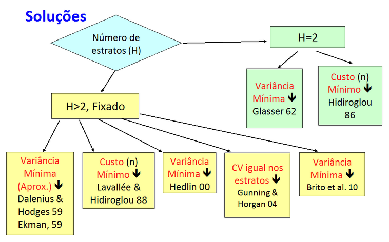

Soluções sobre escolha de número de estratos

### Número de Estratos na Amostragem Estratificada Simples

Para estimação por domínios, recomenda-se utilizar tantos estratos quantos sejam os domínios de interesse.

Para estimação de total ou média global, [@Cochran1977], seção 5A.8, recomenda-se usar até 6 (seis) estratos, se a variável de estratificação for bem correlacionada com as variáveis de interesse,conforme justificativa dada a seguir.

Sob as hipóteses: $N$ grande, $f=n/N$ pequena; o modelo: $y_i = a + bx_i + \varepsilon_i$ para $i \in U$; estratificação “ótima” em $x$; alocação igual nos estratos ($n_h=n/H$), mostra-se que: $EPA\left(\overline y_{AES}\right)=V_{AES}\left(\overline y_{AES}\right)/V_{AAS}\left(\overline y\right)= \rho^2/H^2+\left(1-\rho~2\right)$, onde $\rho$ é correlação entre $x$ e $y$.

A Tabela @ref(tab:efic) apresenta valores de $V_{AES}\left(\overline y_{AES}\right)/V_{AAS}\left(\overline y\right)$ para vários valores de $H$.

$$\textrm{Valores de} V_{AES}\left(\overline y_{AES}\right)/V_{AAS}\left(\overline y\right) \textrm{para vários valores de}\, H$$
$$\begin{array}{ccccccc}\hline
H & 2 & 3 & 4 & 5 & 6 & \infty
\\\hline \rho=0,85 & 0,458 & 0,358 & 0,323 & 0,306 & 0,298 & 0,277
\\ \rho=0,95 & 0,323 & 0,198 & 0,154 & 0,134 & 0,123 & 0,098
\\\hline \end{array}$$

A análise dos resultados acima evidencia que ganhos adicionais de eficiência com mais de seis estratos é modesto.

Na Figura @ref(fig:precisaovsestratos.png) temos o gráfico dos ganhos de precisão versus número de estratos para $\rho=0,85$ e $\rho=0,95$.

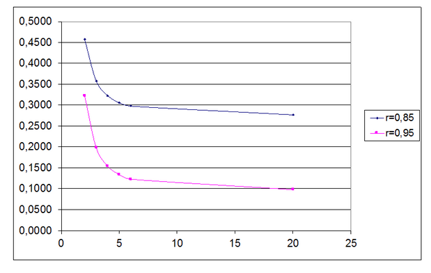

Ganhos de precisão versus número de estratos

## Exercícios

**(#exe:exeest1)** Mostre que a média amostral global $\overline y=\frac{1}{n}\displaystyle\sum_{h=1}^{H}\sum_{i \in a_h}y_{hi}$ pode ser escrita como $\overline y=\displaystyle\sum_{h=1}^{H}\frac{n_h}{n}\overline y_h\ne \sum_{h=1}^{H}\frac{N_h}{N}\overline y_h=\overline y_{AES}$, a menos que $\frac{n_h}{n}=\frac{N_h}{N}, \,\, \forall h=1,\dots,H$ ou seja, a menos que se adote amostragem estratificada simples proporcional ou equiponderada.

**(#exe:exeest2)** Quais são as probabilidades de inclusão de primeira e segunda ordem para unidades na população sob AES? Que valores estas probabilidades assumem em caso de um plano AES proporcional ou equiponderada?

## Referências

Baillargeon, S. & Rivest, L. P. (2011). A General Algorithm for Univariate Stratification. Proceedings of the International Statistical Institute, Dublin.

Brito, J. A. M. (2005). Uma Formulação de Programação Inteira para o Problema de Alocação Ótima em Amostras Estratificadas. In: Anais do XXXVII Simpósio Brasileiro de Pesquisa Operacional - SOBRAPO, Gramado – RS, v. 1. p. 1851-1859.

Brito, J. A. M.; Maculan, N.; Lila, M. F. e Montenegro, F. T. (2010). An exact algorithm for the stratification problem with proportional allocation. Optimization Letters, v. 4, pp. 185 – 195.

Brito, J. A. de M., Silva, P. L. do N., Semaan, G. S., & Maculan, N. (2015). Integer programming formulations applied to optimal allocation in stratified sampling. Survey Methodology, 41(2), 427–442.

Dalenius T. & Hodges Jr., Joseph L. (1959). Minimum Variance Stratification. Journal of the American Statistical Association, Vol. 54, No. 285, pp. 88-101.

Ekman, G. (1959). An Approximation Useful in Univariate Stratification. The Annals of Mathematical Statistics v. 30, p. 219–229.

Glasser, G.J. (1962) On the complete coverage of large units in a statistical study. International Statistical Review, 30, 28-32.

Gunning, P. & Horgan, J.M. (2004). A new algorithm for the construction of stratum boundaries. Survey Methodology, 30, No. 2, 159-166.

Hedlin, D. (2000). A procedure for stratification based on an extended Ekman rule. Journal of Official Statistics, 16, 15-29.

Hidiroglou, M. A. (1986). The construction of a self-representing stratum of large units in survey design. The American Statistician, 40, n. 1, 27-31.

Lavallée, P. & Hidiroglou, M. A. (1988). On the stratification of skewed populations. Survey Methodology, 14, 33-43.

Rivest, L. P. (2002). A generalization of the Lavallée-Hidiroglou algorithm for stratification in business surveys. Survey Methodology 28, 191-198.